## Assignment 8 Solutions

#### Due Friday, October 30, 11:59 PM CT

### 1

> Read in the `chimpanzee.csv` data file. Make a plot that displays the overall relative frequencies for making the prosocial choice; do this separately for the trials when a partner is present and when there is no partner present. (That is, plot a point estimate of the sample proportion for the trials with and without a parter.)  
> Use a thin blue line segment to visualize a 95% confidence interval, a slightly thicker black segment to visualize the interval one standard error above and below the point estimate, and a point at the point estimate. Add a horizontal red dashed line at p = 0.5. Label axes appropriately and add an informative title to the plot.

Hint: Your final plot should have two vertical lines (with the layered segments noted in the question), a point in the center of each vertical line, and a horizontal line.

#### Solution

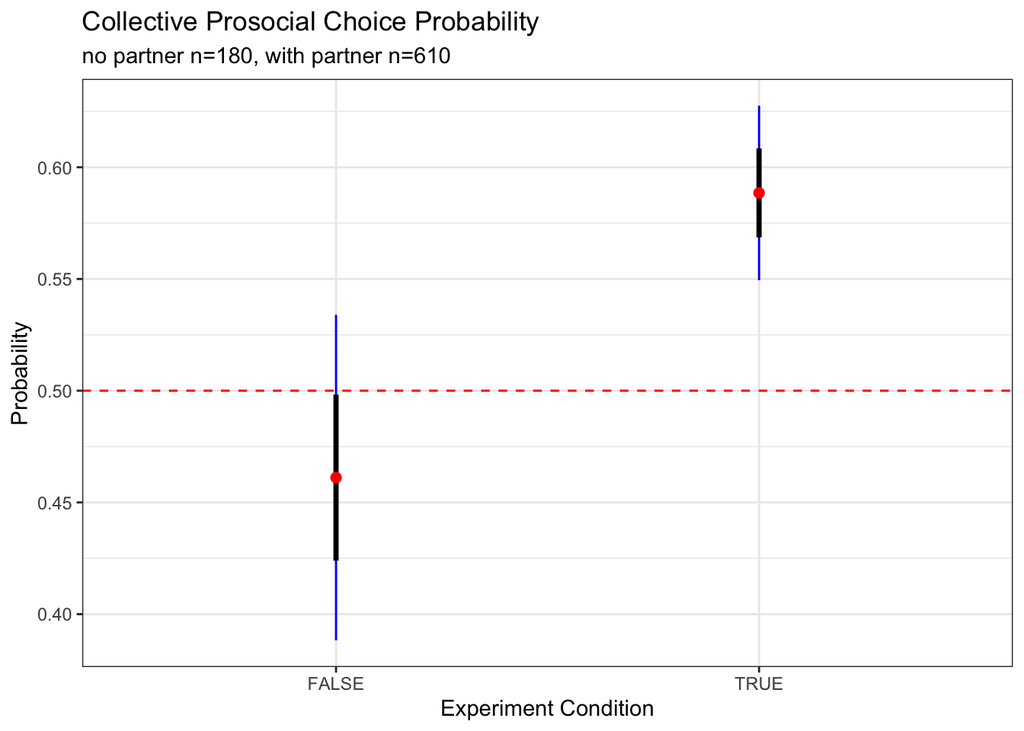

```r
## Solution
chimps <- read_csv("../../data/chimpanzee.csv") %>%
  mutate(with_partner = case_when(
    partner == "none" ~ FALSE,
    TRUE ~ TRUE)) %>%
  select(actor,partner,with_partner,everything())

df_1 <- chimps %>%
  group_by(with_partner) %>%
  summarize(prosocial = sum(prosocial),
            selfish = sum(selfish),
            n = prosocial + selfish,
            p_hat = prosocial / n,
            se = sqrt(p_hat*(1-p_hat)/n))

ggplot(df_1,aes(x=with_partner, xend=with_partner)) +
  geom_segment(aes(y=p_hat-1.96*se,yend=p_hat+1.96*se), color="blue") +
  geom_segment(aes(y=p_hat-se,yend=p_hat+se), size=1.2) +
  geom_point(aes(y=p_hat), color="red", size=2) +
  geom_hline(yintercept=0.5,color="red",linetype="dashed") +
  xlab("Experiment Condition") +
  ylab("Probability") +
  ggtitle("Collective Prosocial Choice Probability",
          subtitle = "no partner n=180, with partner n=610") + theme_bw()
```

### 2

> Consider Chimpanzee actor F in the setting with a partner present. Compute 99%, 95%, 90%, and 80% Wald confidence intervals for p, the probability of selecting the prosocial token. Print out all four confidence intervals.

#### Solution

```r
## Solution
chimpf <- chimps %>%
  filter(actor == "F", with_partner) %>%
  group_by(with_partner) %>%
  summarize(prosocial = sum(prosocial),
            selfish = sum(selfish),
            n = prosocial + selfish,
            p_hat = prosocial / n,
            se = sqrt(p_hat*(1-p_hat)/n))

compute_ci_wald <- function(df, confidence_level=.95){
  z <- qnorm(1 - (1-confidence_level)/2)
  df <- df %>%
    mutate(
      lower = p_hat - z*se,
      upper = p_hat + z*se
    )
  out <- c(df$lower, df$upper)
  return(out)
}

compute_ci_wald(chimpf, .99)
```

```
## [1] 0.3865982 0.6578462
```

```r
compute_ci_wald(chimpf, .95)
```

```
## [1] 0.4190251 0.6254193
```

```r
compute_ci_wald(chimpf, .90)
```

```
## [1] 0.4356165 0.6088280
```

```r
compute_ci_wald(chimpf, .80)
```

```
## [1] 0.4547453 0.5896992
```